# Aides Drug

Alison Jimenez

11/17/2026

# Introduction

A new preventative aides drug (triUmpsal) is under test in clinical trials. Consider only the females, does this drug seem effective? Hint - use dplyr to obtain that sub population with the filter command.

The question is whether the drug triUmpsal appears to make a difference when compared with a placebo. The focus is on female participants in the clinical trial. By comparing the infection outcomes of females who received triUmpsal with those who received a placebo to find out if the relationships between treatment received and the likelihood of becoming infected and to determine the data provides evidence that triUmpsal may be an effective preventative treatment for females.

```r
female <- triUmp %>%
filter(gender == "F")

names(female)
```

```
## [1] "X"         "treatment" "infected"  "LGBTQ"     "DrugUser"  "gender"
```

```r
table(female$treatment)
```

```
##
##    drug placebo
##    5694    6074
```

# Methods

We use two categorical variables. Treatment identifies whether female participants received triUmpsal or a placebo. Infection status whether participants became infected with AIDS or remained uninfected.

categorical - treatment

categorical - infection status

# Results

### Graphical Descriptive Results

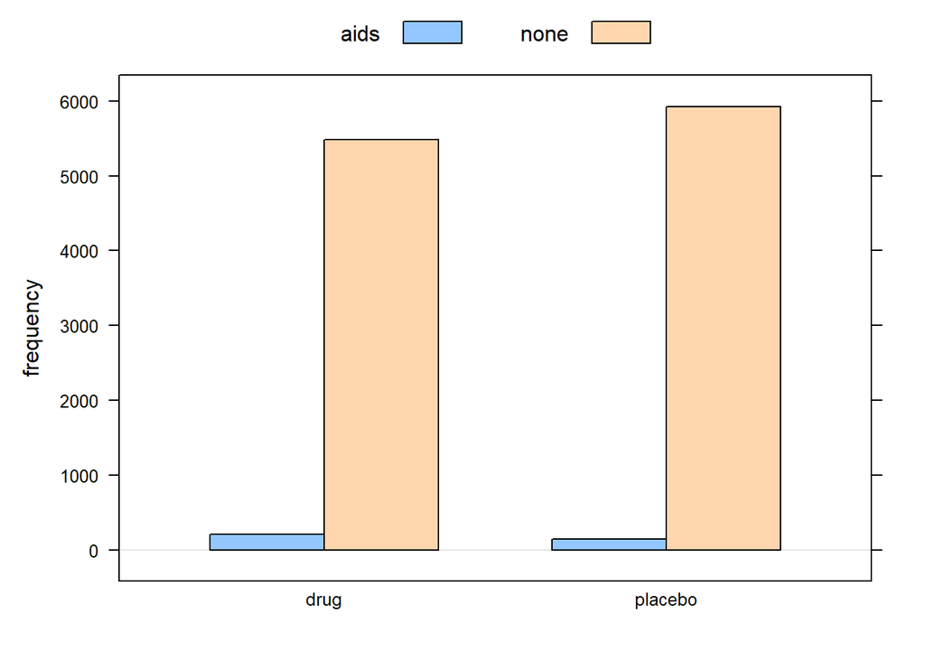

```r
barchartGC(~treatment+ infected,data=female)
```

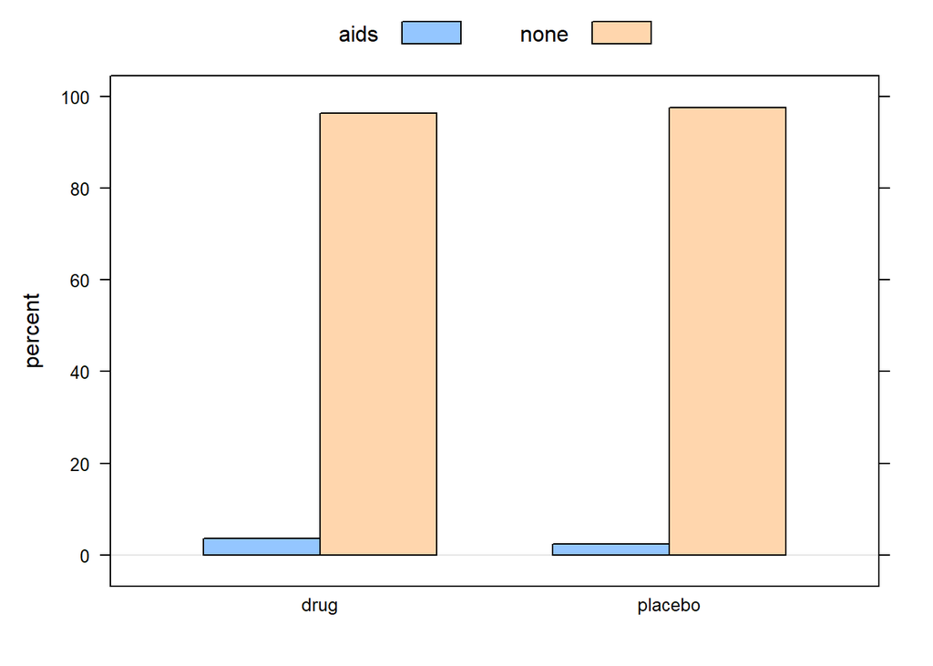

```r
barchartGC(~treatment + infected,data=female, type="percent")
```

The first bar graph illustrates the frequency of both the infected and the uninfected females who participated from the drugs and placebo groups. The graph on the other hand, demonstrates that 210 females who received triUmpsal did become infected compared to the 147 females who received just the placebo. But because the two treatment groups contain different number of participants the percentage of the graph provides stronger data. The second graph shows that 3.69% of females in the drug group became infected, compared to 2.42% in the group with placebos. This shows that the percentage of infected participants were higher among those who did receive triUmpsal.

### Numerical Descriptive Results

```r
table1 <- xtabs(~treatment + infected, data=female)
rowPerc(table1)
```

```
##          infected
## treatment   aids   none  Total
##   drug      3.69  96.31 100.00
##   placebo   2.42  97.58 100.00
```

```r
colPerc(table1)
```

```
##          infected
## treatment   aids   none
##   drug     58.82  48.06
##   placebo  41.18  51.94
##   Total   100.00 100.00
```

```r
table1
```

```
##          infected
## treatment aids none
##   drug     210 5484
##   placebo  147 5927
```

The numerical results demonstrate a difference in infection outcomes between female participants who received triUmsal and those who received the placebo from the 5,694 females who received the drug, 210 became infected, representing 3.69% of the group compared to, the 6.074 females who received the placebo, 147 became infected, representing 2.42% of the group. Additionally, 96.31% of females in the group remained uninfected, compared to 97.58% in the placebo group. Showing that the drug group had a higher infection rate than the placebo group.

## Inferential Results

```r
chisq.test(table1)
```

```
##
##  Pearson's Chi-squared test with Yates' continuity correction
##
## data:  table1
## X-squared = 15.634, df = 1, p-value = 7.686e-05
```

```r
chisqtestGC(table1)
```

```
## Pearson's Chi-squared test with Yates' continuity correction
##
## Observed Counts:
##          infected
## treatment aids none
##   drug     210 5484
##   placebo  147 5927
##
## Counts Expected by Null:
##          infected
## treatment   aids    none
##   drug    172.74 5521.26
##   placebo 184.26 5889.74
##
## Contributions to the chi-square statistic:
##          infected
## treatment aids none
##   drug    8.04 0.25
##   placebo 7.54 0.24
##
##
## Chi-Square Statistic = 15.6339
## Degrees of Freedom of the table = 1
## P-Value = 1e-04
```

```r
fisher.test(table1)
```

```
##
##  Fisher's Exact Test for Count Data
##
## data:  table1
## p-value = 6.596e-05
## alternative hypothesis: true odds ratio is not equal to 1
## 95 percent confidence interval:
##  1.240408 1.925729
## sample estimates:
## odds ratio
##   1.543902
```

The inferential result findings conclude that all three P values are below 0.05 meaning we reject the $H_0$. There is statistically substantial evidence of a relationship between the treatment group and infection status among female participants. Suggesting that triUmpsal did not show the expected preventive effect among female participants in this data set.

# Discussion and Conclusion

The results of this study do not support the expectation that triUmpsal prevents HIV infection among female participants. Both the graphical and numerical results show a higher percentage of infections among females who received the drug compared to those who received the placebo. Specifically, 3.69% of females in the drug group became infected, compared to 2.42% in the placebo group. The inferential results of 0.05 further show that this difference was statistically significant, resulting in us rejecting the null hypothesis. In conclusion the study suggest that triUmpsal was not effective at preventing HIV infection among the female participants in this study, the participants who received the drug had a higher infection rate than those who received the placebo.